# Labo 2 : Evaluation of results obtained from ElastricSearch

## Peiris Sébastien & Raemy Mathis

## Date: 17.11.2021

## Introduction

Dans ce laboratoire, il nous a été demandé de réaliser une étude comparative de quatre analyseurs ("standard", "whitespace", "english" et "english avec la liste des mots communs") dans un système d'IR. Pour ce faire, nous avons dans un premier temps calculé différentes métriques en fonction d'un jeu de requêtes donné.

Pour chaque requête, nous avons pu calculer la précision, le rappel ou encore la moyenne de ces métriques.

```python
import matplotlib.pyplot as plt
```

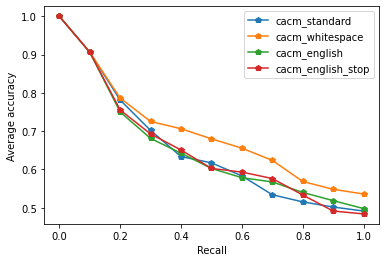

```python
# insert manally data
data = [
    {
        "index_name" : "cacm_standard",
        "avg_precision_at_recall_level" : [1.0,0.90625,0.7812500000000002,0.7018229166666666,0.6335937500000002,0.6171874999999998,0.5831101190476189,0.5338355654761904,0.5152839781746029,0.5018663194444447,0.4913831394300141]
    },
    {
        "index_name" : "cacm_whitespace",
        "avg_precision_at_recall_level" : [1.0,0.90625,0.7864583333333336,0.7252604166666666,0.7062500000000004,0.6799479166666663,0.6555803571428575,0.6235863095238094,0.5685267857142855,0.5481398809523811,0.5358529491341989]
    },
    {
        "index_name" : "cacm_english",
        "avg_precision_at_recall_level" : [1.0,0.90625,0.7500000000000002,0.6809895833333331,0.6424479166666668,0.6026041666666665,0.5784970238095236,0.5673363095238094,0.5399615575396824,0.5184709821428574,0.4978112599206348]
    },
    {
        "index_name" : "cacm_english_stop",
        "avg_precision_at_recall_level" : [1.0,0.90625,0.7552083333333335,0.6927083333333331,0.6507812500000001,0.6026041666666667,0.5930803571428571,0.5762648809523809,0.5332093253968253,0.4914062500000004,0.48388347763347755]
    }
]
for d in data:
    x = [j/10 for j in range(len(d["avg_precision_at_recall_level"]))]
    plt.plot(x,d["avg_precision_at_recall_level"], '-p', label=d["index_name"])
    plt.xlabel("Recall")
    plt.ylabel("Average accuracy")
plt.legend()
plt.show()
```

## Conclusion

On peut voir que les 4 courbes ont globalement une forme similaires à ce que l'on peut attendre d'une courbe de **Recall-Precision Graph**. En effet pour les 4 analyzers on voit une régression de la précision en fonction du rappel.

Nous avons également remarqué que la courbe **cacm_whitespace** se démarque légèrement vers le milieu de la fonction. Celon nous, elle devrait plutôt se démarquer vers le bas. En effet a cause des mots utilisé dans presque tous les textes en anglais (stop_words) on devrait obtenir un nombre total de document beaucoup plus grand de document. Cela a cause de la présence de ces mots "fréquents" dans presque tous les documents. Donc comme le nombre de documents est plus élevé, cela devrait avoir tendance a faire plutôt **baisser** la précision et **augmenter** le recall.

On a également remarqué que les deux courbes **cacm_english** et **cacm_english_stop** sont très similaires car ils ont certainement une base de mots bannis similaires.